# FOXP3

Forkhead-Box-Protein P3

Peter N Robinson, Dominik Seelow

Berlin Institute of Health

2026-10-26

## FOXP3

**Protein family**  
A member of the fork-winged helix family of transcription factors

**Function**

Important for the development and function of naturally occurring CD4+/CD25+ T regulatory cells (Tregs)

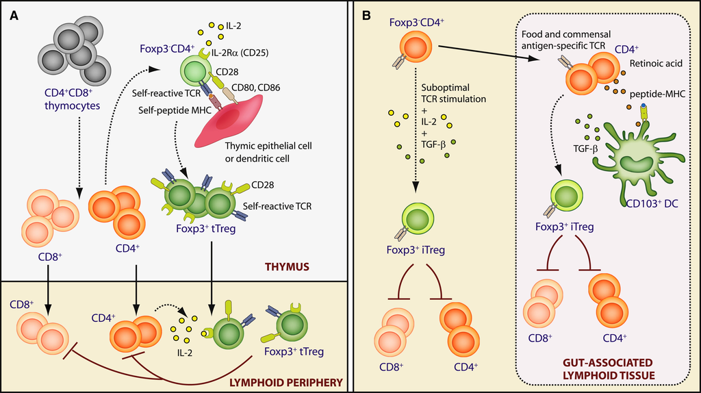

Josefowicz SZ, Rudensky A. (2009) [Control of regulatory T cell lineage commitment and maintenance. *Immunity* **30**:616-25](https://pubmed.ncbi.nlm.nih.gov/19464984/)

## HPO

**Disease annotated with HPO terms**  
[Immunodysregulation, polyendocrinopathy, and enteropathy, X-linked](https://hpo.jax.org/browse/disease/OMIM:304790)

[figure not shown]

## Small intestine

[interactive chart not shown]

Human Reference Atlas Small Intestine

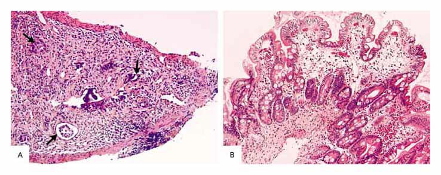

A duodenal-biopsy specimen: a flattened mucosa with absent or necrotic crypts

- [Villous atrophy (HP:0011473)](https://hpo.jax.org/browse/term/HP:0011473)

## Pancreas

[interactive chart not shown]

Human Reference Atlas Pancreas

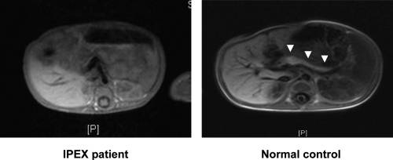

Absence of recognizable pancreatic tissue of a patient with classic IPEX syndrome (c.227delT, p.Leu74GlnfsX53 mutation).

- [Type I diabetes mellitus (HP:0100651)](https://hpo.jax.org/browse/term/HP:0100651)

image: [Rubio-Cabezas O, et al. (2009) Clinical heterogeneity in patients with FOXP3 mutations presenting with permanent neonatal diabetes. *Diabetes Care* **32**:111-6](https://pubmed.ncbi.nlm.nih.gov/18931102/)

## Skin

[interactive chart not shown]

**HPO term**  
[Eczematoid dermatitis HP:0000964](https://hpo.jax.org/browse/term/HP:0000964)

[figure not shown]

**Predicted effect**  
[Open the MutationTaster result](https://teide.charite.de/MT2021/MutationTaster102.cgi?gene=foxp3&transcript_stable_id_text=ENST00000376207&transcript_stable_id_radio=ENST00000376207&new_base=A&sequence_type=CDS&position_be=1150)

## What would a neutral variant look like?

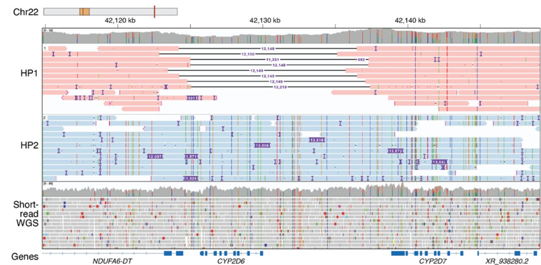

Every individual has between 4-5 million variants, the vast majority of which are benign. But how do we know they are benign?

MutationTaster: benign, c.155G>T / G52V<sup>1</sup>

[^1]: NM_014009/ENST00000376207.4 / chr23:49114808C>A (GRCh37)